# Diagonal Maximum Likelihood Estimation

Andrea Ferrero

2025-11-17

## 1. Idea and Motivation

The goal is to perform estimation on the copula parameter $\theta$. Standard approach in copula estimation would be classical maximum likelihood.

However, standard MLE requires evaluation of the copula density, which in high dimension can be cumbersome or even impossible (d > 220 is not implemented in the copula package for gumbel copula and others).

The advantage of this other approach introduced in Hofert is that it is fast and does not scale bad in high dimensions. Actually, as suggested by Hofert, an increasing number of dimension can be useful in providing information on the dependence between the variables.

Everything relies on the idea that the diagonal $\delta_{\theta}(u)$ is the distribution of $Y_i = max(U_j)$ for $j = 1, \dots, d$.

An estimator can therefore be obtained by:

$$\hat{\theta}_n = argsup_\theta \sum_{i = 1}^n log {\delta^\prime}_\theta
(Y_i)$$

For the Gumbel copula, the estimator has even a closed form:

$$\hat{\theta}_n^G = \frac{log d}{log n - log(\sum_{i = 1}^n - log
Y_i)}$$

If one takes ${\hat{\theta}_n^G}^* = max(\hat{\theta}_n^G, 1)$, he’s guaranteed to have a valid estimator.

## 2. Application to Archimedean copulas (Gumbel case)

The method is easily applicable to Archimedean copulas as their diagonal and its derivative have a simple analytic form:

$$\delta_{\theta}(u) = \psi_\theta(d \psi_\theta^{-1}(u)) \, , \;
\delta^{\prime}_{\theta}(u) = d \psi_\theta^{\prime}(d
\psi_\theta^{-1}(u)) {(\psi_\theta^{-1})}^\prime(u)$$

Once the diagonal has been evaluated in its analytic form, estimation can be performed by optimising the likelihood numerically.

Below we can see a comparison of the estimated parameter (true value is $\theta = 1.5$) for a gumbel copula with increasing observations (K) with d = 12.

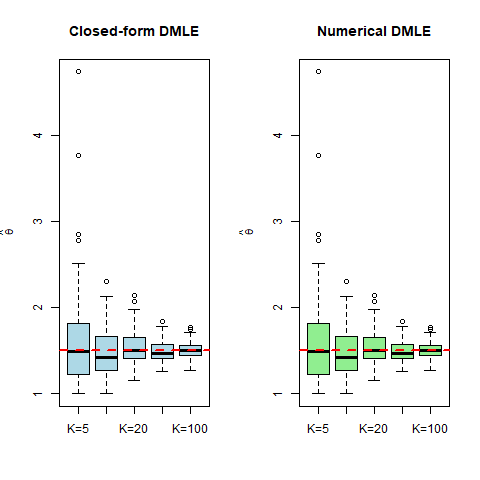

## 3. Precision and Dependence

The precision of the estimator was found to degree rapidly when performing DMLE with increasing dependence ($\theta > 4$), due to the instability of the estimates. This has led to the necessity to cut off the estimated values by only retaining values in (1, 10). Below we see the result with $\theta = 4$.

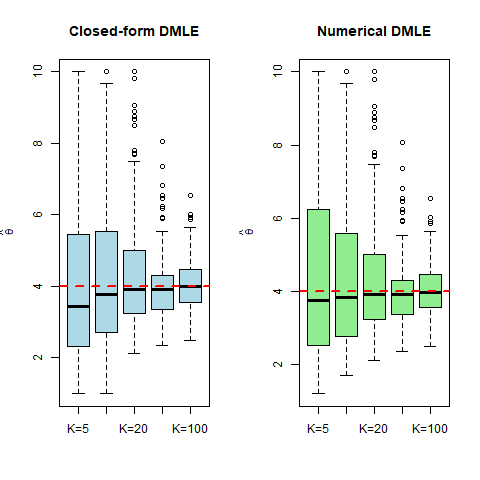

This was found to be connected to how the loglikelihood changes with increasing values of theta:

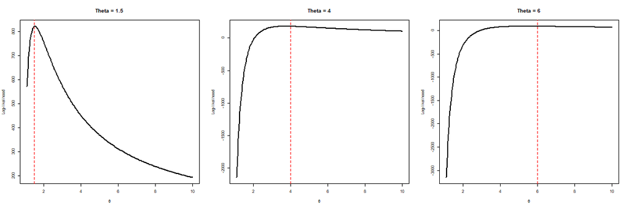

Intuitively this can be explained by how the diagonal stores the available information.

The Gumbel copula diagonal is the following:

$$\boxed{
\delta_\theta(u) = u^{\, d^{1/\theta}}
}.$$

For $\theta \to \infty$, the exponent $a(\theta) = d^{\frac{1}{\theta}} \to 1$, therefore the diagonal gets closer to the identity function.